# Chronic Absenteeism Report: 2025–26 (Preliminary)

Polk County Schools

Author

Affiliation

Dr. Shaun Kellogg

AttendNC Counts, Office of Research and Promising Practices, NCDPI

Published

September 8, 2026

## Introduction

**WarningPreliminary Data — 2025–26**

School-level CA rates in this report are from the **preliminary 2025–26 release** and may change before final publication. Subgroup data for economically disadvantaged (EDS), students with disabilities (SWD), and English learners (ELS) are not yet available in the 2025–26 preliminary release, so the point-in-time subgroup equity chart is limited to All Students and racial/ethnic groups. The subgroup trend chart is the exception: it draws on finalized historical data and shows all eight subgroups through 2024–25, with All Students, racial/ethnic groups, and Multiracial students extending into the 2025–26 preliminary release. The bright spot school map uses **2024–25 final identifications**, which will be updated when the full 2025–26 dataset is available.

Chronic absenteeism, defined as missing 10% or more of enrolled school days, remains one of the most persistent post-pandemic challenges in K–12 education. This report examines the 2025–26 chronic absenteeism (CA) landscape across the 7 traditional public schools of Polk County Schools, comparing each school’s preliminary performance to the district average, the state average, and what would be expected given its economic context.

The district’s enrollment-weighted CA rate in 2025–26 is **25.8%**, compared to a statewide traditional-LEA average of 25.3%. School-level rates range from 10.7% to 31.5%. A key thread throughout this report is the distinction between schools that are above or below the poverty-adjusted expectation — controlling for economic disadvantage helps reveal meaningful variation that raw rates alone can obscure.

**TipHow to read this report**

- **CA rate** is the share of students chronically absent (missing ≥10% of school days).
- **Poverty-adjusted performance** asks: given how many students in a school are experiencing economic hardship, how does the school’s CA rate compare to what we’d expect? We fit a trend line through all 2476 matched traditional public schools in North Carolina using the share of economically disadvantaged students to predict each school’s CA rate. A school’s **residual** is the gap between its actual and predicted rates — a **negative number means better than expected** for its poverty level; a positive number means worse.
- Colors throughout: **Blue = better than expected for poverty level · Orange = worse than expected**.

## School Snapshot

### CA Rates by School

Schools are ranked by preliminary 2025–26 CA rate. Color reflects poverty-adjusted performance: blue bars are performing better than their poverty level would predict, orange bars are performing worse.

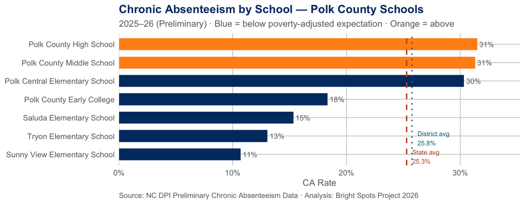

### School Summary

The table below summarizes key metrics for each school: preliminary 2025–26 CA rate, historical peak, improvement since peak, performance relative to state and district averages, and the poverty-adjusted residual.

**Polk County Schools — Chronic Absenteeism Summary by School**

2025–26 School Year (Preliminary) · Traditional public schools · State avg: **25.3%** · District avg: **25.8%**

[output not shown]

## Trends Over Time

### School Trajectories, 2018–2026

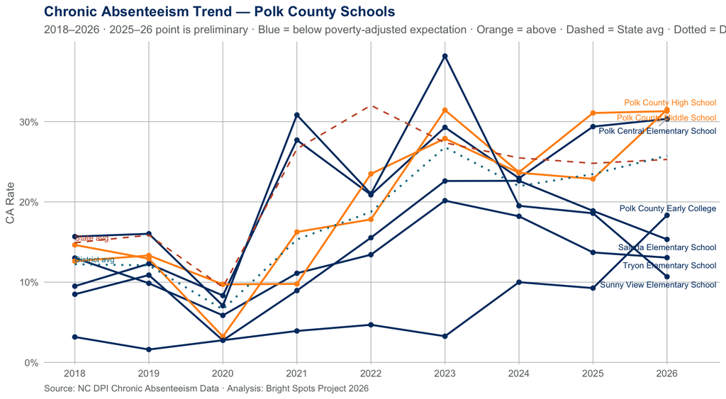

### Subgroup Trends, 2018–2026

The chart below shows Polk County Schools’s enrollment-weighted average CA rates by student subgroup (solid lines) compared to statewide averages for the same subgroups (dashed lines), covering every subgroup available in the historical data. All Students, Black, White, Hispanic, and Multiracial lines extend through the 2025–26 preliminary release; Econ. Disadvantaged, Students w/ Disabilities, and English Learners are not yet available for 2025–26 and their lines end at 2024–25.

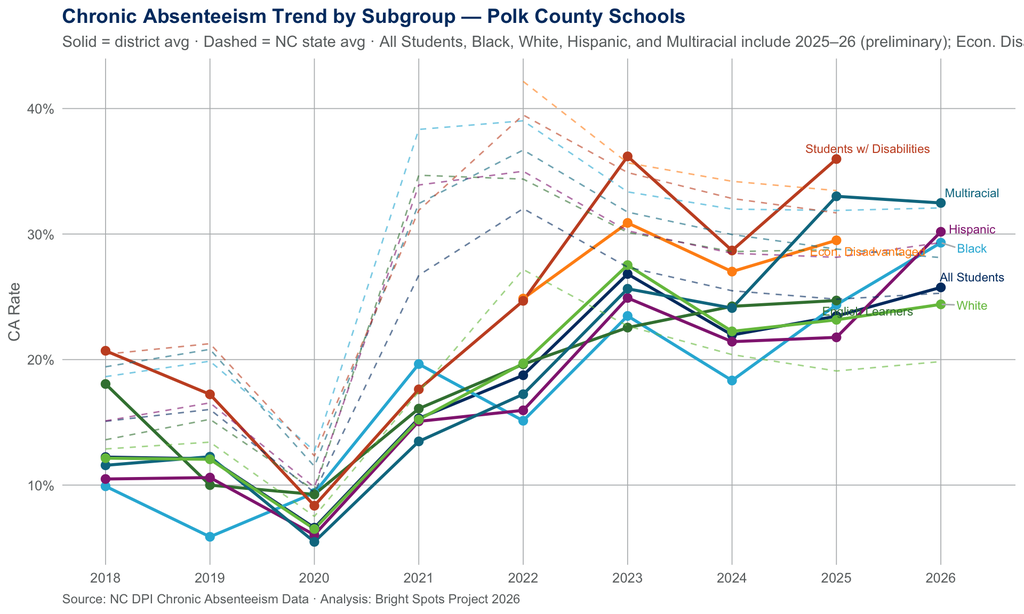

## Poverty-Adjusted Performance

### Schools in Statewide Context

The chart below shows all 2476 matched traditional public schools in North Carolina (gray dots), each plotted by its preliminary 2025–26 CA rate and its share of economically disadvantaged students. The diagonal line represents the CA rate a school would be *expected* to have given its poverty level. Schools below the line are doing better than expected; schools above it are doing worse. Polk schools are highlighted in blue (better than expected) or orange (worse than expected).

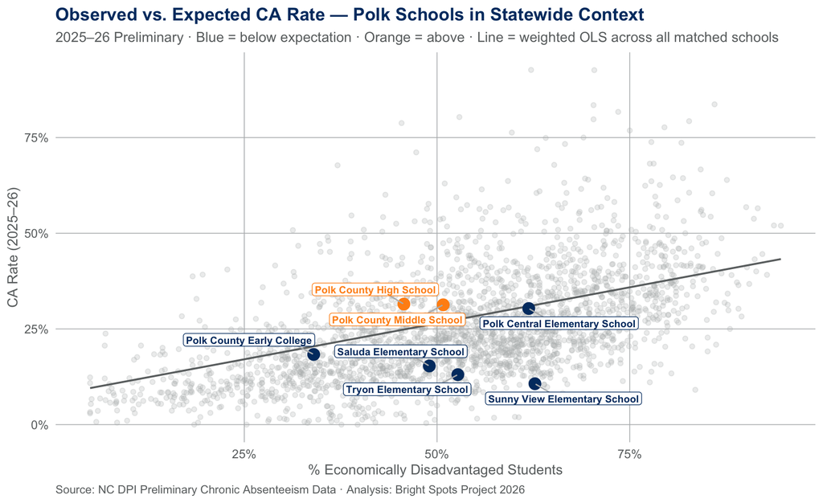

## Subgroup Equity

The chart below compares preliminary 2025–26 CA rates by student subgroup across Polk schools. Gray dots are individual school rates; the blue circle is the enrollment-weighted district average; the orange diamond is the statewide average. EDS and SWD data are not yet available in the preliminary release.

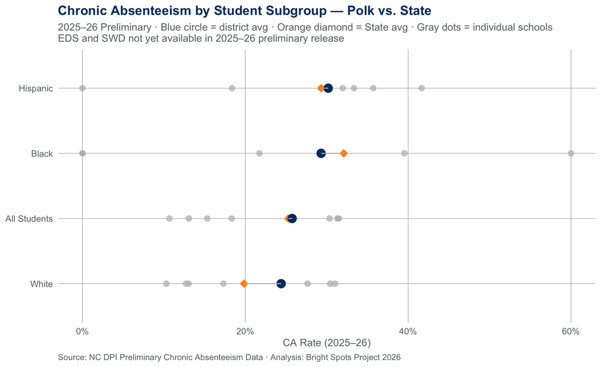

## School Deep Dives

The two sections below examine **Sunny View Elementary School**, which carries the lowest poverty-adjusted residual among Polk’s traditional schools (-20.6 pp vs. expectation), and **Polk County High School**, which carries the largest positive residual (+6.6 pp). Each school is examined through three lenses: historical trajectory, subgroup breakdown, and comparison to peer schools statewide with similar poverty levels.

### Sunny View Elementary School

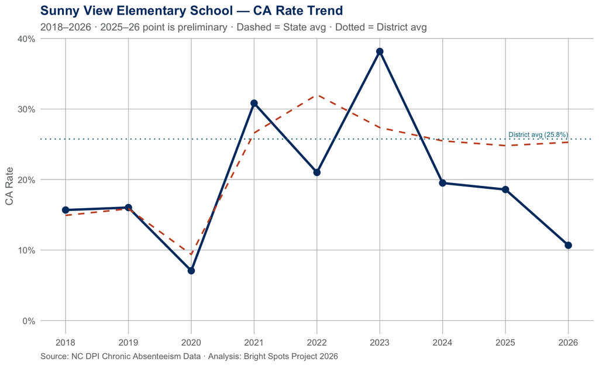

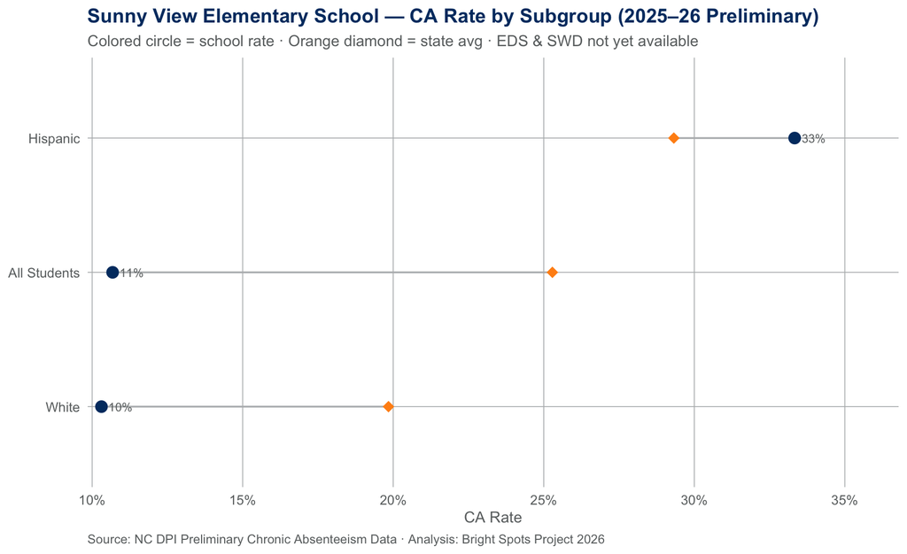

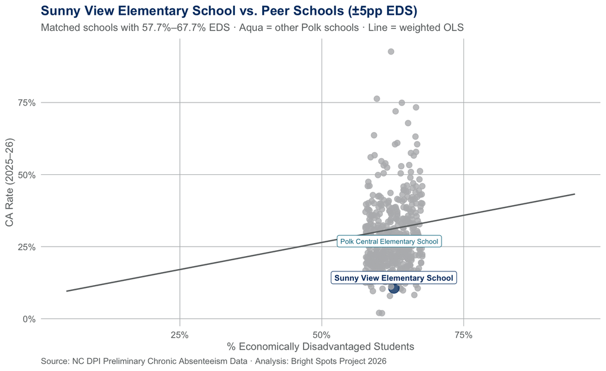

### Polk County High School

Polk County High School serves 597 students in grades 9:12. At 45.7% EDS, its preliminary 2025–26 CA rate of 31.5% is 6.2 pp above the state average. Its poverty-adjusted residual of 6.6 pp is the largest positive residual in the district, indicating challenges that extend beyond what its poverty level alone would predict.

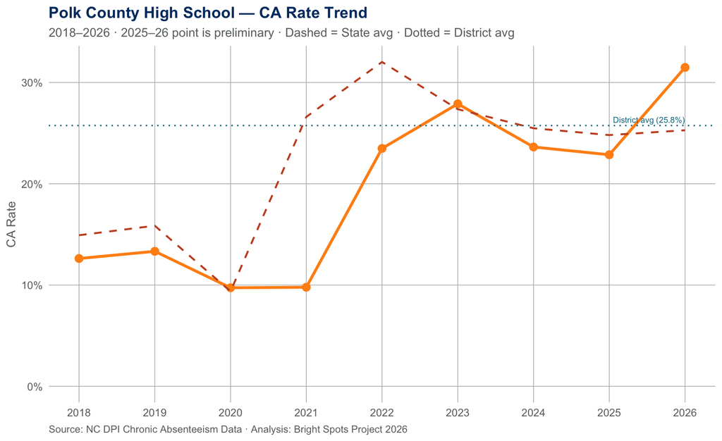

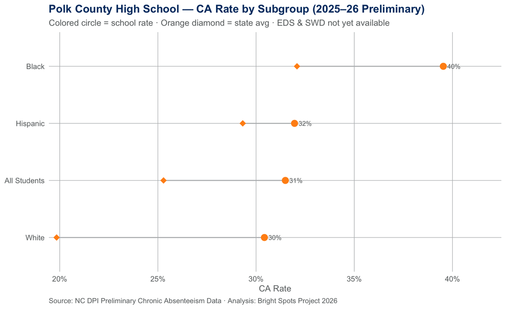

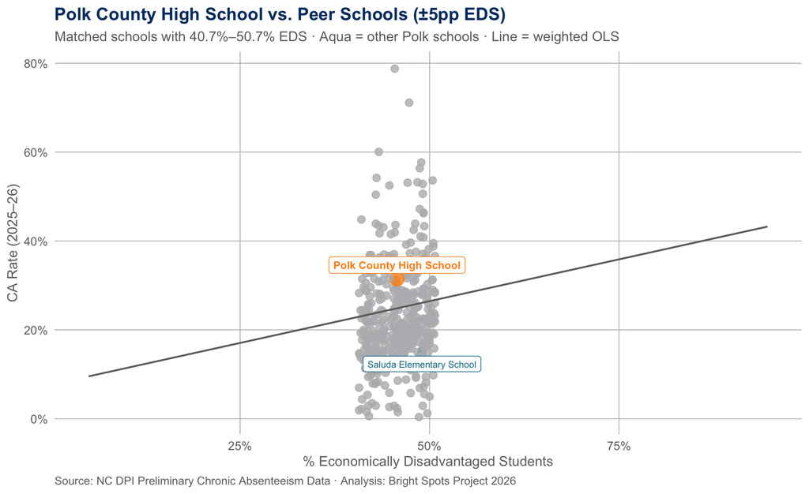

## Bright Spot Schools

**Note2024–25 Bright Spot Identifications**

The map below uses **2024–25 final bright spot identifications**. The value-added model will be rerun when the full 2025–26 dataset is released. No schools in Polk County Schools were identified as 2024–25 Bright Spot candidates.

No schools in Polk County Schools are identified as 2024–25 Bright Spot candidates. Nearby schools in surrounding districts can serve as peer-learning opportunities.

The interactive map below shows all 2024–25 Bright Spot candidates statewide, zoomed to the area around Polk. Markers are colored by grade band; click any marker for details.

[interactive chart not shown]

**NoteThree questions to guide your exploration**

- **Who is improving in a context like ours?** Use the grade band and poverty level of Polk’s schools to identify peer schools worth learning from.
- **Which schools are the clearest bright spots?** The **Exceptional**, **Strong**, and **Promising** tiers indicate how far a school is outperforming model expectations — start with Exceptional schools for the strongest signal.
- **Where should we learn more?** Use the table on the [AttendNC Bright Spots Dashboard](https://sbkellogg.shinyapps.io/bright-spots-app-v2/) to identify schools worth reaching out to, visiting, or inviting into a peer-learning conversation.

If your school is a bright spot and you’d like to share what worked, [submit a practice here](https://forms.cloud.microsoft/r/vAG6SC1Kye).

## Methodology Notes

**Data source.** School-level chronic absenteeism data for 2025–26 are from a preliminary release (`Prelim_ChronicAbsenteeism_2526.xlsx`) and may change before final publication. Historical data (2017–18 through 2024–25) are from NC DPI’s finalized chronic absenteeism files. Analyses are restricted to traditional public school LEAs with a record in the 2024–25 pipeline.

**School inclusion.** This report includes 1 school omitted from the standard 2024-25 modeling pipeline used to build school_2025_sector_results: **Polk County Early College** (no usable 2021-22 enrollment baseline). Their 2025-26 rates are drawn directly from the preliminary release, and their historical ‘peak’ values use the actual 2021-22 rate (or, where no 2021-22 record exists, the 2025-26 rate itself) rather than the pipeline’s adjusted baseline. As a result, this district’s enrollment-weighted average and school count may differ slightly from prior reports that restricted to pipeline-matched schools only.

**Subgroup availability.** The preliminary 2025–26 data includes All Students and racial/ethnic subgroups only. EDS, SWD, and ELS breakdowns are not yet available and will be incorporated in the final dataset.

**School-level aggregation.** All CA rates are computed directly from school-level numerators and denominators. The district average is the enrollment-weighted aggregate across all Polk County Schools schools with 2025–26 data.

**Poverty-adjusted residuals.** A weighted OLS model (`p_current ~ pct_eds`, weighted by enrollment) was fit across 2476 matched traditional public schools using 2025–26 preliminary CA rates and 2025–26 EDS rates (APR 2026). Negative residual = better than expected for poverty level.

**Bright spot identification.** Bright spot schools are identified using a beta-binomial mixed-effects model fit to 2024–25 finalized data. This analysis will be rerun on final 2025–26 data when available. See the [AttendNC Bright Spots](https://www.dpi.nc.gov/districts-schools/office-research-promising-practices/attendnc-counts/attendnc-bright-spots) page for full methodology.